# FoodHub Data Analysis

### Context

The number of restaurants in New York is increasing day by day. Lots of students and busy professionals rely on those restaurants due to their hectic lifestyles. Online food delivery service is a great option for them. It provides them with good food from their favorite restaurants. A food aggregator company FoodHub offers access to multiple restaurants through a single smartphone app.

The app allows the restaurants to receive a direct online order from a customer. The app assigns a delivery person from the company to pick up the order after it is confirmed by the restaurant. The delivery person then uses the map to reach the restaurant and waits for the food package. Once the food package is handed over to the delivery person, he/she confirms the pick-up in the app and travels to the customer's location to deliver the food. The delivery person confirms the drop-off in the app after delivering the food package to the customer. The customer can rate the order in the app. The food aggregator earns money by collecting a fixed margin of the delivery order from the restaurants.

### Objective

The food aggregator company has stored the data of the different orders made by the registered customers in their online portal. They want to analyze the data to get a fair idea about the demand of different restaurants which will help them in enhancing their customer experience. Suppose you are hired as a Data Scientist in this company and the Data Science team has shared some of the key questions that need to be answered. Perform the data analysis to find answers to these questions that will help the company to improve the business.

### Data Description

The data contains the different data related to a food order. The detailed data dictionary is given below.

### Data Dictionary

- order_id: Unique ID of the order
- customer_id: ID of the customer who ordered the food
- restaurant_name: Name of the restaurant
- cuisine_type: Cuisine ordered by the customer
- cost: Cost of the order
- day_of_the_week: Indicates whether the order is placed on a weekday or weekend (The weekday is from Monday to Friday and the weekend is Saturday and Sunday)
- rating: Rating given by the customer out of 5
- food_preparation_time: Time (in minutes) taken by the restaurant to prepare the food. This is calculated by taking the difference between the timestamps of the restaurant's order confirmation and the delivery person's pick-up confirmation.
- delivery_time: Time (in minutes) taken by the delivery person to deliver the food package. This is calculated by taking the difference between the timestamps of the delivery person's pick-up confirmation and drop-off information

### Importing the required libraries

```python
# import libraries for data manipulation
import numpy as np
import pandas as pd

# import libraries for data visualization
import matplotlib.pyplot as plt
import seaborn as sns
```

### Understanding the structure of the data

```python
# read the data
df = pd.read_csv('foodhub_order.csv')
# returns the first 5 rows
df.head()
```

|  | order_id | customer_id | restaurant_name | cuisine_type | cost_of_the_order | day_of_the_week | rating | food_preparation_time | delivery_time |
| --- | --- | --- | --- | --- | --- | --- | --- | --- | --- |
| 0 | 1477147 | 337525 | Hangawi | Korean | 30.75 | Weekend | Not given | 25 | 20 |
| 1 | 1477685 | 358141 | Blue Ribbon Sushi Izakaya | Japanese | 12.08 | Weekend | Not given | 25 | 23 |
| 2 | 1477070 | 66393 | Cafe Habana | Mexican | 12.23 | Weekday | 5 | 23 | 28 |
| 3 | 1477334 | 106968 | Blue Ribbon Fried Chicken | American | 29.20 | Weekend | 3 | 25 | 15 |
| 4 | 1478249 | 76942 | Dirty Bird to Go | American | 11.59 | Weekday | 4 | 25 | 24 |

#### Observations:

The DataFrame has 9 columns as mentioned in the Data Dictionary. Data in each row corresponds to the order placed by a customer.

```python
df.shape
```

```
(1898, 9)
```

#### Observations:

The Data has 1898 rows and 9 columns.

```python
# Use info() to print a concise summary of the DataFrame
df.info()
```

```
<class 'pandas.core.frame.DataFrame'>
RangeIndex: 1898 entries, 0 to 1897
Data columns (total 9 columns):
 #   Column                 Non-Null Count  Dtype
---  ------                 --------------  -----
 0   order_id               1898 non-null   int64
 1   customer_id            1898 non-null   int64
 2   restaurant_name        1898 non-null   object
 3   cuisine_type           1898 non-null   object
 4   cost_of_the_order      1898 non-null   float64
 5   day_of_the_week        1898 non-null   object
 6   rating                 1898 non-null   object
 7   food_preparation_time  1898 non-null   int64
 8   delivery_time          1898 non-null   int64
dtypes: float64(1), int64(4), object(4)
memory usage: 133.6+ KB
```

#### Observations:

The data types are 1 float 64, 4 int64, and 4 objects.

They are categorized as follows: order_id, customer_id, restaurant_name, cuisine_type, cost_of_the_order, day_of_the_week, rating, food_preparation_time, and delivery_time.

#### Checking for missing values

```python
df.isnull().sum()
```

```
order_id                 0
customer_id              0
restaurant_name          0
cuisine_type             0
cost_of_the_order        0
day_of_the_week          0
rating                   0
food_preparation_time    0
delivery_time            0
dtype: int64
```

#### Observations:

There are no missing values in the data.

```python
df.describe(include='all').T
```

|  | count | unique | top | freq | mean | std | min | 25% | 50% | 75% | max |
| --- | --- | --- | --- | --- | --- | --- | --- | --- | --- | --- | --- |
| order_id | 1898.0 | NaN | NaN | NaN | 1477495.5 | 548.049724 | 1476547.0 | 1477021.25 | 1477495.5 | 1477969.75 | 1478444.0 |
| customer_id | 1898.0 | NaN | NaN | NaN | 171168.478398 | 113698.139743 | 1311.0 | 77787.75 | 128600.0 | 270525.0 | 405334.0 |
| restaurant_name | 1898 | 178 | Shake Shack | 219 | NaN | NaN | NaN | NaN | NaN | NaN | NaN |
| cuisine_type | 1898 | 14 | American | 584 | NaN | NaN | NaN | NaN | NaN | NaN | NaN |
| cost_of_the_order | 1898.0 | NaN | NaN | NaN | 16.498851 | 7.483812 | 4.47 | 12.08 | 14.14 | 22.2975 | 35.41 |
| day_of_the_week | 1898 | 2 | Weekend | 1351 | NaN | NaN | NaN | NaN | NaN | NaN | NaN |
| rating | 1898 | 4 | Not given | 736 | NaN | NaN | NaN | NaN | NaN | NaN | NaN |
| food_preparation_time | 1898.0 | NaN | NaN | NaN | 27.37197 | 4.632481 | 20.0 | 23.0 | 27.0 | 31.0 | 35.0 |
| delivery_time | 1898.0 | NaN | NaN | NaN | 24.161749 | 4.972637 | 15.0 | 20.0 | 25.0 | 28.0 | 33.0 |

#### Observations:

The minimum time to prepare food is 20 minutes. The average time to prepare food is 27.37 minutes. The maximum time to prepare food is 35 minutes.

### Find the orders that are not rated.

```python
#Orders not rated
df['rating'].value_counts()
```

```
Not given    736
5            588
4            386
3            188
Name: rating, dtype: int64
```

#### Observations:

736 orders are not rated

### Exploratory Data Analysis (EDA)

### Order ID

```python
#order_id
df['order_id'].nunique()
```

```
1898
```

### Customer ID

```python
#customer_id
df['customer_id'].nunique()
```

```
1200
```

### Restaurant Name

```python
#restaurant_name
df['restaurant_name'].nunique()
```

```
178
```

### Cuisine Type

```python
#cuisine_type

df['cuisine_type'].nunique()
```

```
14
```

```python
df['cuisine_type'].unique()
```

```
array(['Korean', 'Japanese', 'Mexican', 'American', 'Indian', 'Italian',
       'Mediterranean', 'Chinese', 'Middle Eastern', 'Thai', 'Southern',
       'French', 'Spanish', 'Vietnamese'], dtype=object)
```

```python
df['cuisine_type'].value_counts()
```

```
American          584
Japanese          470
Italian           298
Chinese           215
Mexican            77
Indian             73
Middle Eastern     49
Mediterranean      46
Thai               19
French             18
Southern           17
Korean             13
Spanish            12
Vietnamese          7
Name: cuisine_type, dtype: int64
```

[output not shown]

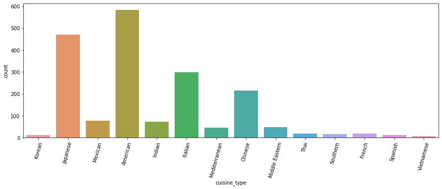

```python
plt.figure(figsize=(15,5))
sns.countplot(data=df, x='cuisine_type')
plt.xticks(rotation =75)
```

### Cost of the order

```python
df['cost_of_the_order'].mean()
```

```
16.498851422550082
```

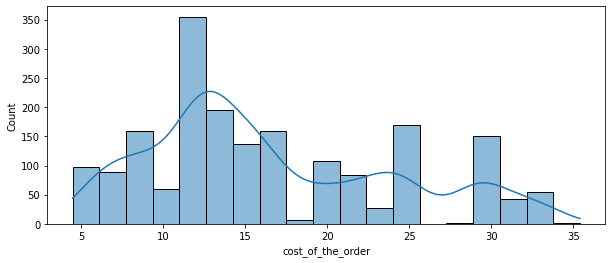

```python
plt.figure(figsize=(10,4))
sns.histplot(data=df, x='cost_of_the_order', kde=True);
```

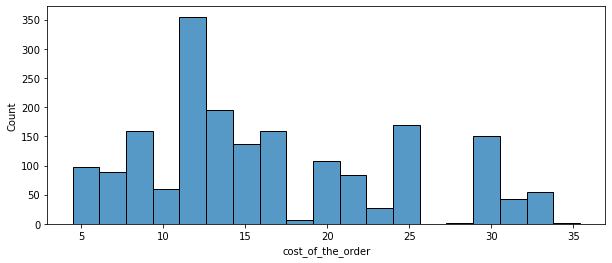

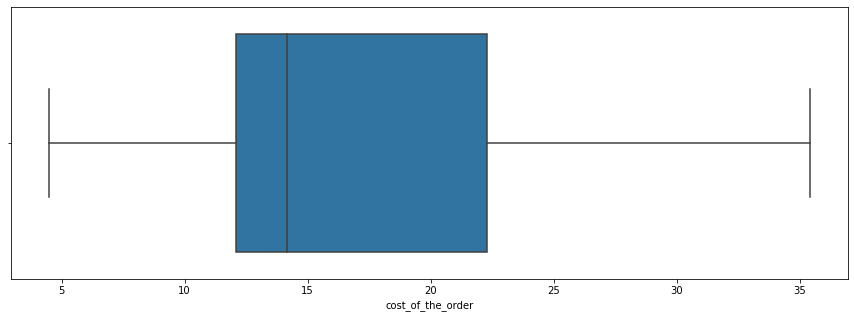

```python
plt.figure(figsize=(10,4))
sns.histplot(data=df, x='cost_of_the_order')
plt.show()
plt.figure(figsize=(15,5))
sns.boxplot(data=df, x='cost_of_the_order');
```

### Day of the Week

```python
df['day_of_the_week'].unique()
```

```
array(['Weekend', 'Weekday'], dtype=object)
```

```
(array([0, 1]), [Text(0, 0, 'Weekend'), Text(1, 0, 'Weekday')])
```

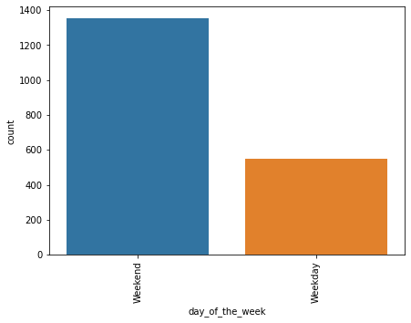

```python
plt.figure(figsize=(7,5))
sns.countplot(data=df, x='day_of_the_week')
plt.xticks(rotation =90)
```

```python
df['rating'].unique()
```

```
array(['Not given', '5', '3', '4'], dtype=object)
```

```
(array([0, 1, 2, 3]),
 [Text(0, 0, 'Not given'), Text(1, 0, '5'), Text(2, 0, '3'), Text(3, 0, '4')])
```

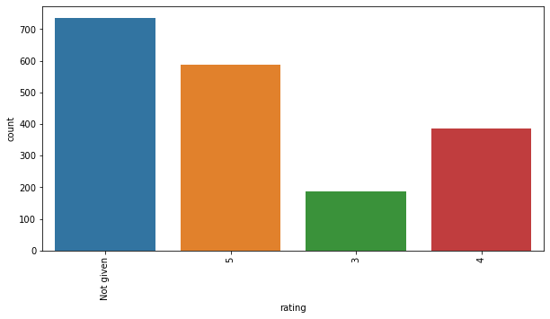

```python
plt.figure(figsize=(10,5))
sns.countplot(data=df, x='rating')
plt.xticks(rotation =90)
```

### Food Preparation Time

```python
df['food_preparation_time'].mode()
```

```
0    21
dtype: int64
```

```python
df['food_preparation_time'].mean()
```

```
27.371970495258168
```

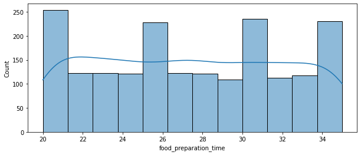

```python
plt.figure(figsize=(10,4))
sns.histplot(data=df, x='food_preparation_time', kde=True);
```

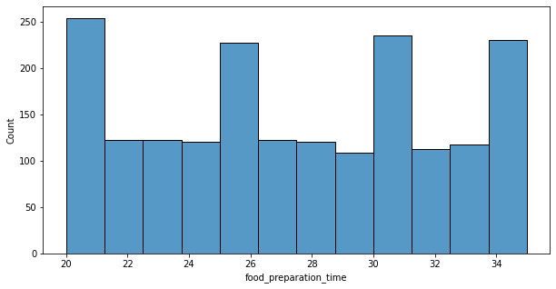

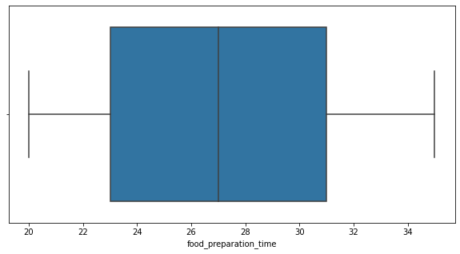

```python
plt.figure(figsize=(10,5))
sns.histplot(data=df, x='food_preparation_time')
plt.show()
plt.figure(figsize=(10,5))
sns.boxplot(data=df, x='food_preparation_time');  #Preparation time in minutes
```

### Delivery Time

```python
#Mean of delivery time
df['delivery_time'].mean()
```

```
24.161749209694417
```

```python
#Mode of delivery time
df['delivery_time'].mode()
```

```
0    24
dtype: int64
```

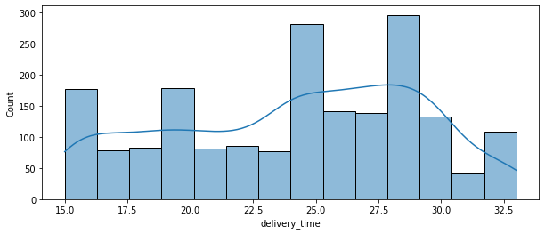

```python
plt.figure(figsize=(10,4))
sns.histplot(data=df, x='delivery_time', kde=True);
```

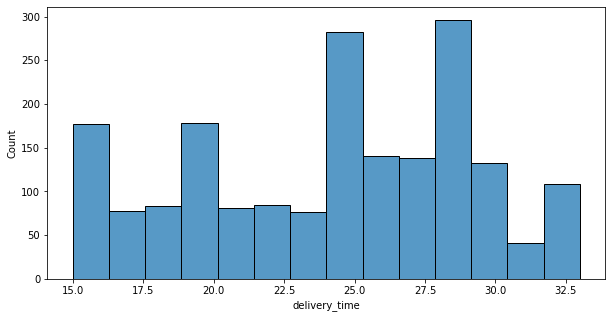

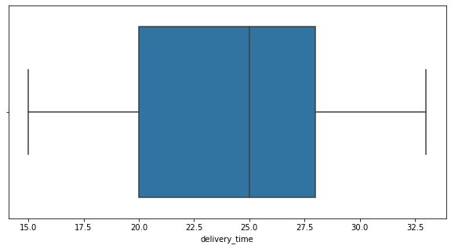

```python
plt.figure(figsize=(10,5))
sns.histplot(data=df, x='delivery_time')
plt.show()
plt.figure(figsize=(10,5))
sns.boxplot(data=df, x='delivery_time'); #Delivery time in minutes
```

### Observations:

There are 1898 orders in the dataset from 1200 customers

There are 178 restaurants in the dataset

There are 14 different types of cuisine. Korean, Japanese, Mexican, American, Indian, Italian, Mediterranean, Chinese, Middle Eastern, Thai, Southern, French, Spanish, and Vietnamese.

American was the most popular cuisine followed by Japanese and Italian. Vietnamese, Spanish, and Korean were the least popular cuisines.

The average cost of an order is $16.50.

The minimum order cost was $4.47.

The maximum order cost was $35.41.

The number of orders on the weekend are more than twice the amount than on the weekday.

For the customers who completed a rating, 5 was the most popular score.

The average time to prepare food orders was 27.37 minutes.

The average time to deliver food orders was 24.16 minutes.

#### Identify which restaurants had the most orders

```python
df['restaurant_name'].value_counts().head(5)
```

```
Shake Shack                  219
The Meatball Shop            132
Blue Ribbon Sushi            119
Blue Ribbon Fried Chicken     96
Parm                          68
Name: restaurant_name, dtype: int64
```

#### Observations:

Shake Shack, The Meatball Shop, Blue Ribbon Sushi, Blue Ribbon Fried Chicken, and Parm received the most orders.

#### Identify the most popular cuisines on the weekend

```python
df_weekends =df[df['day_of_the_week']== 'Weekend']
df_weekends['cuisine_type'].value_counts()
```

```
American          415
Japanese          335
Italian           207
Chinese           163
Mexican            53
Indian             49
Mediterranean      32
Middle Eastern     32
Thai               15
French             13
Korean             11
Southern           11
Spanish            11
Vietnamese          4
Name: cuisine_type, dtype: int64
```

[output not shown]

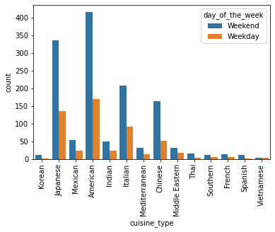

```python
sns.countplot(data=df, x='cuisine_type', hue='day_of_the_week')
plt.xticks(rotation=90)
```

#### Observations:

The most popular cuisine on the weekends is American.

#### What percentage of the orders cost more than 20 dollars?

```python
df_more_than_20 = df[df['cost_of_the_order']>20]
print('Number of orders more than $20 is:', df_more_than_20.shape[0])

percentage = (df_more_than_20.shape[0] / df.shape[0]) * 100
print('Percent of orders more than $20 is:', round(percentage, 2),'%')
```

```
Number of orders more than $20 is: 555
Percent of orders more than $20 is: 29.24 %
```

#### What is the average time of delivery of orders?

```python
df['delivery_time'].mean()
```

```
24.161749209694417
```

#### Observations:

The mean order delivery time is 24.16 minutes.

### The company has decided to give 20% discount voucher to the top 5 most frequent customers. Identify which customers qualify for the discount.

Identify the top 5 customers

```python
df['customer_id'].value_counts().head()
```

```
52832     13
47440     10
83287      9
250494     8
259341     7
Name: customer_id, dtype: int64
```

### Correlation matrix of all variables.

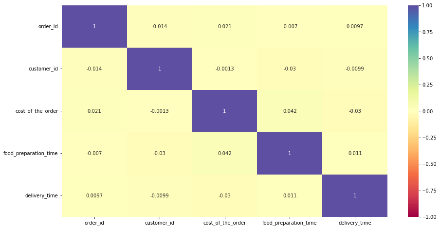

```python
#col_list= ['cost_of_the_order','food_preparation_time', 'delivery_time']
plt.figure(figsize=(15,8))
sns.heatmap(df.corr(),annot=True, cmap='Spectral', vmin=-1, vmax=1)
plt.show()
```

### Customer ID

```python
#Top 10 customer's with the most order's placed
df['customer_id'].value_counts().head(10)
```

```
52832     13
47440     10
83287      9
250494     8
259341     7
82041      7
65009      7
276192     7
97079      6
97991      6
Name: customer_id, dtype: int64
```

### Restaurant Name

```python
#Restaurants with only 1 order
df['restaurant_name'].value_counts().tail(50)
```

```
Le Zie 2000 Trattoria            1
Cafe de La Esquina               1
Sarabeth's West                  1
Frank Restaurant                 1
Hiroko's Place                   1
Rye House                        1
Lamarca Pasta                    1
67 Burger                        1
Lucky Strike                     1
Paul & Jimmy's                   1
Hampton Chutney Co.              1
Wa Jeal                          1
Hunan Manor                      1
Moonstruck on Second             1
Il Bambino                       1
Nha Trang One                    1
Market Table                     1
Emporio                          1
Galli Restaurant                 1
Coppola's East                   1
Kori Restaurant and Bar          1
Woorijip                         1
Crema Restaurante                1
The MasalaWala                   1
Anjappar Chettinad               1
Big Wong Restaurant _¤¾Ñ¼       1
Klong                            1
Haru Gramercy Park               1
Chote Nawab                      1
Pepe Giallo                      1
Taro Sushi                       1
Samurai Mama                     1
Hibino                           1
Balade                           1
Posto                            1
Kambi Ramen House                1
Wo Hop Restaurant                1
Spice Thai                       1
Gaia Italian Cafe                1
Chola Eclectic Indian Cuisine    1
Rohm Thai                        1
Dig Inn Seasonal Market          1
Socarrat Paella Bar              1
Alidoro                          1
Cipriani Le Specialita           1
Sushi Choshi                     1
Dos Caminos Soho                 1
La Follia                        1
Philippe Chow                    1
'wichcraft                       1
Name: restaurant_name, dtype: int64
```

### Cuisine Type vs. Cost of the order

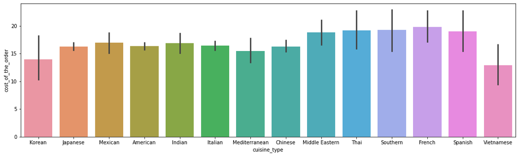

```python
#Cuisine type vs Cost of the order
plt.figure(figsize=(18,5))
sns.barplot(data=df, x='cuisine_type', y='cost_of_the_order');
```

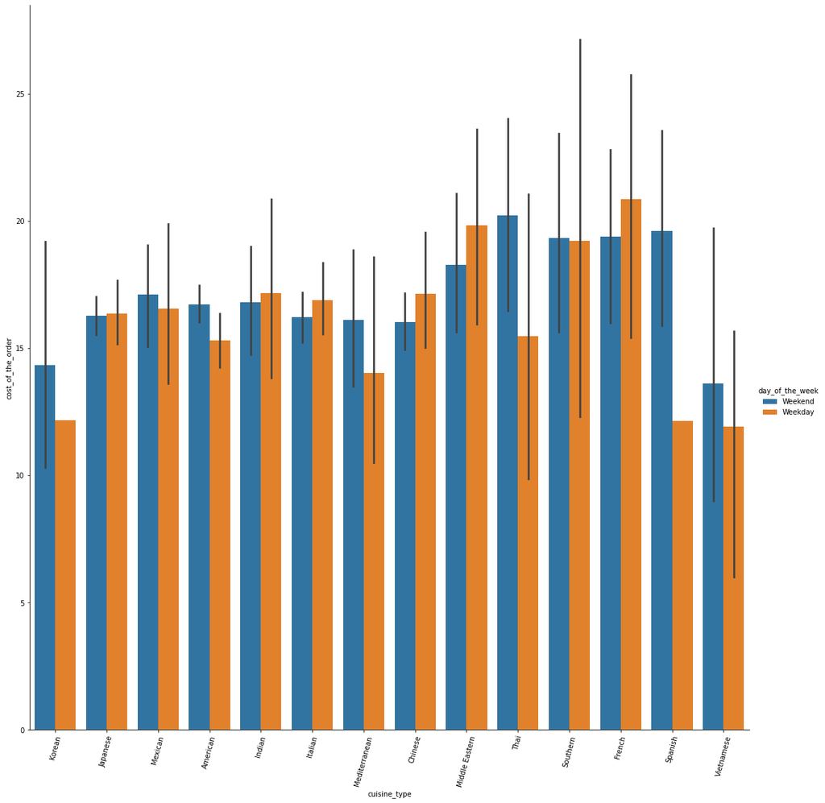

```python
#Cuisine type vs. Cost of the order
plt.figure(figsize=(20,7))
sns.catplot(x='cuisine_type', y='cost_of_the_order', data=df, kind='bar', hue='day_of_the_week',height=15, aspect=1)
plt.xticks(rotation=75)
plt.show()
```

### Cuisine Type vs. Food Preparaton Time

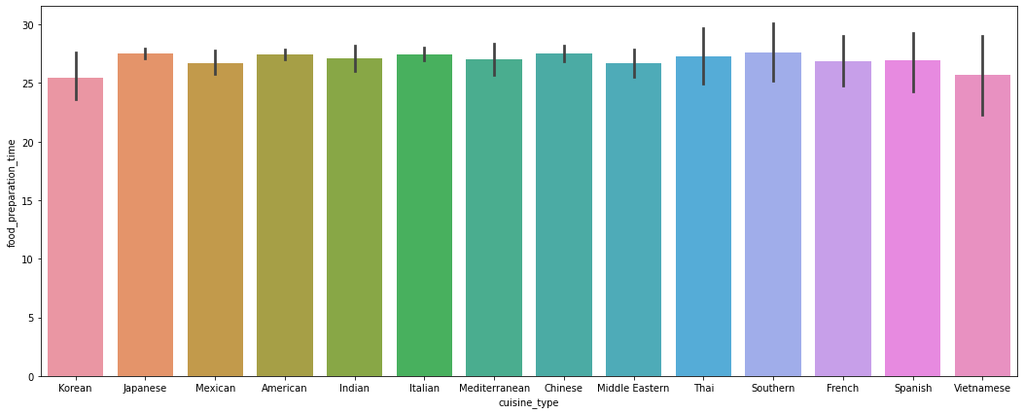

```python
plt.figure(figsize=(18,7))
sns.barplot(data=df, x='cuisine_type', y='food_preparation_time');
```

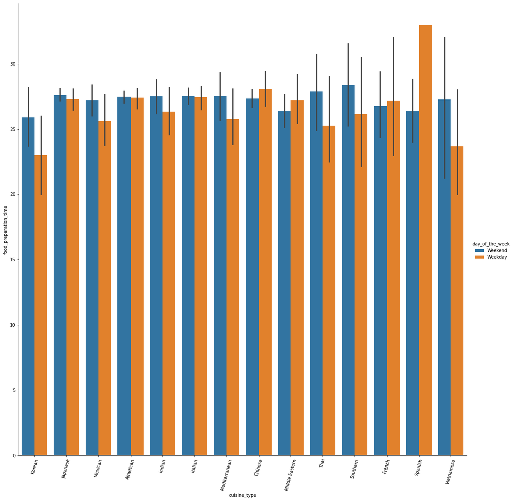

```python
sns.catplot(x='cuisine_type', y='food_preparation_time', data=df, kind='bar', hue='day_of_the_week', height=15, aspect=1)
plt.xticks(rotation=75)
plt.show()
```

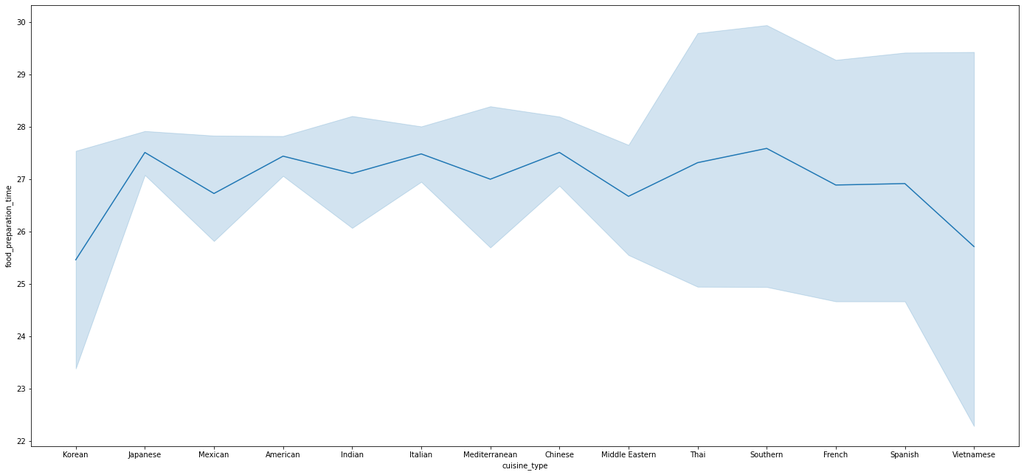

```python
plt.figure(figsize=(24,11))
sns.lineplot(data=df, x='cuisine_type', y='food_preparation_time')
```

### Cuisine Type vs. Delivery Time

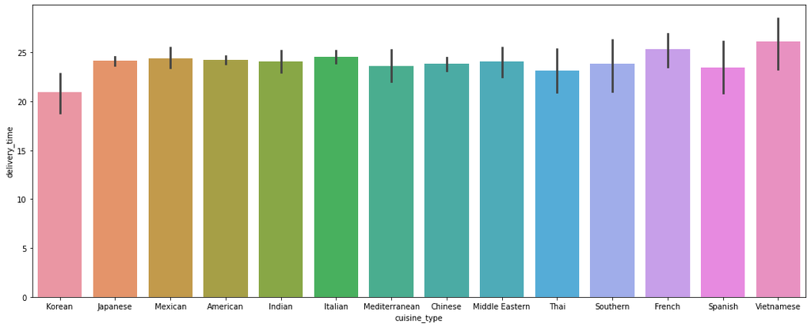

```python
plt.figure(figsize=(18,7))
sns.barplot(data=df, x='cuisine_type', y='delivery_time');
```

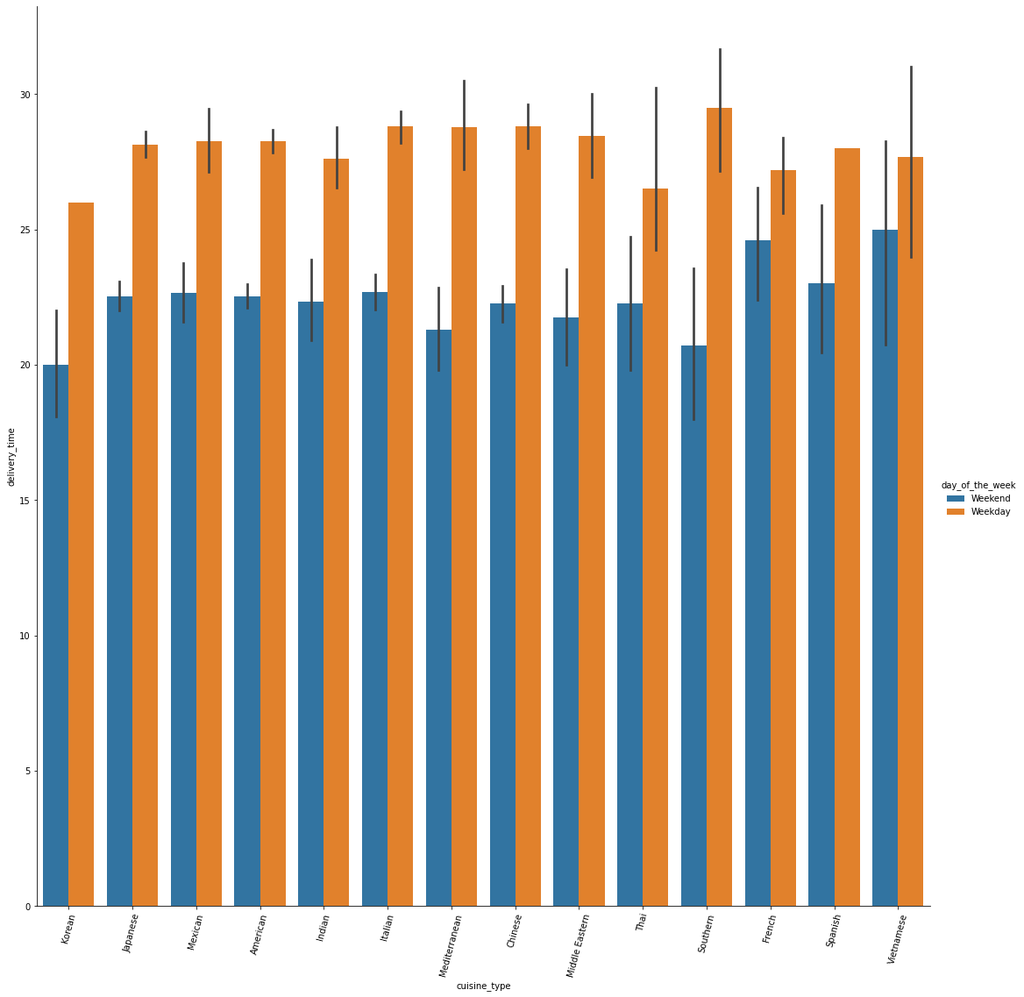

```python
plt.figure(figsize=(22,9))
sns.catplot(x='cuisine_type', y='delivery_time', data=df, kind='bar', hue='day_of_the_week', height=15, aspect=1)
plt.xticks(rotation=75)
plt.show()
```

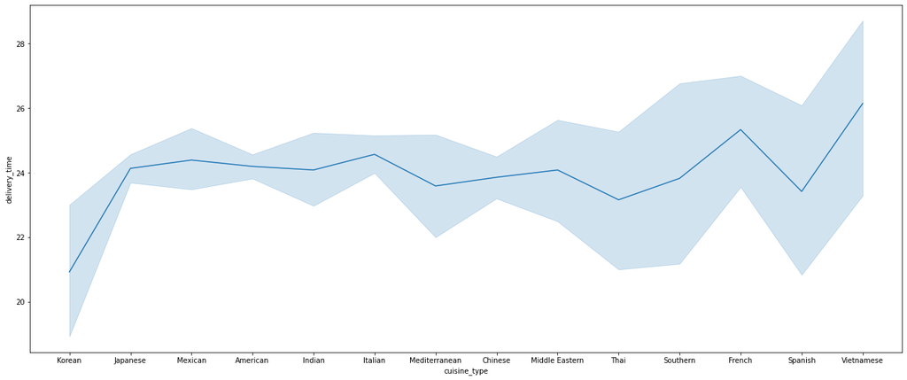

```python
plt.figure(figsize=(22,9))
sns.lineplot(data=df, x='cuisine_type', y='delivery_time');
```

### Day of the week vs. Food Preparation Time

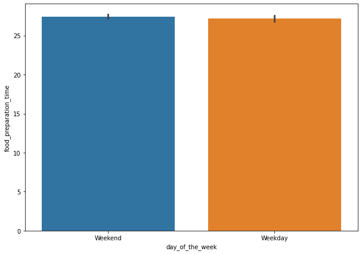

```python
plt.figure(figsize=(10,7))
sns.barplot(data=df, x='day_of_the_week', y='food_preparation_time');
```

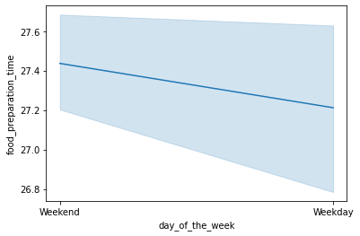

```python
sns.lineplot(data=df, x='day_of_the_week', y='food_preparation_time');
```

### Day of the Week vs. Delivery Time

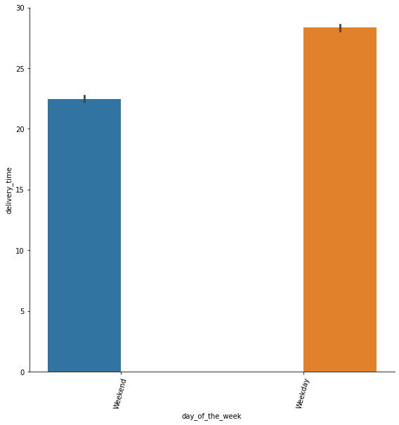

```python
plt.figure(figsize=(2,1))
sns.catplot(x='day_of_the_week', y='delivery_time', data=df, kind='bar', hue='day_of_the_week', height=8, aspect=1)
plt.xticks(rotation=75)
plt.show()
```

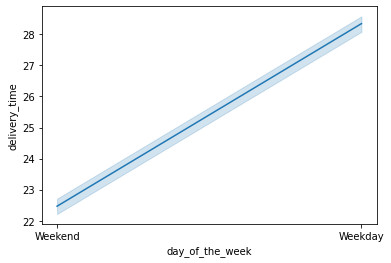

```python
sns.lineplot(data=df, x='day_of_the_week', y='delivery_time');
```

### Rating vs. Cost of Order

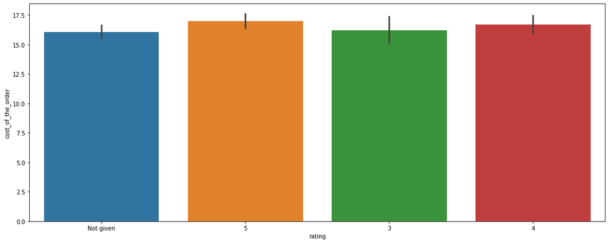

```python
plt.figure(figsize=(18,7))
sns.barplot(data=df, x='rating', y='cost_of_the_order');
```

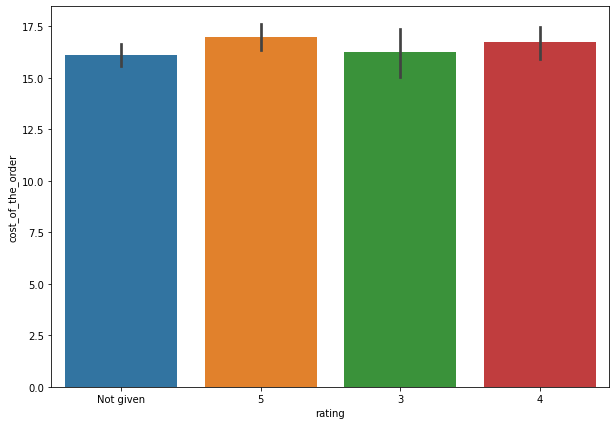

```python
plt.figure(figsize=(10,7))
sns.barplot(data=df, x='rating', y='cost_of_the_order');
```

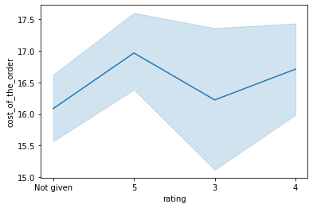

```python
sns.lineplot(data=df, x='rating', y='cost_of_the_order');
```